# Rgl Updated

Nicholas Norcia

December 4th, 2018

## What is Rgl?

Rgl provides medium to high level functions for 3D interactive graphs. The output may be on the screen using OpenGL, or to various 3D file formats, and even 2D image formats.

Multiple windows are managed at one time. If you code a graph and the window is not open r will open the window. This window is now focused on what you just typed. The focus can be changed with rgl.set() or useSubscene3d().

## Functions of Rgl

Rgl creates a new window, unlike a simple plot which uses the viewer tab. You will mostly have to look at your Rgl plot in another window. It opens a small interactive window that you can manipulate with your cursor. You can add many different things to this window, including surface area or even making 3D objects.

### open3d()

Opens a new RGL window, using defaults or inputs determined by the user.

```r
library(rgl)
open3d()
```

```
## wgl
##   1
```

This gives you a glimpse of the Rgl interactive window.

If you have been working with rgl and need to if any windows are open, check3d(), is perfect.

### .check3d()

This function checks to see if there are any open Rgl windows. It returns a number value with which window is open.

```r
.check3d()
```

```
## wgl
##   1
```

### abclines3d()

Adds a mathematical line to a scence. Will be displayed at intersection with bounding box.

```r
# rgl.abclines(x, y = NULL, z = NULL, a, b = NULL, c = NULL, ...)
# abclines3d(x, y = NULL, z = NULL, a, b = NULL, c = NULL, ...)

# x,y,z are points for the line and a,b,c are the directional vectors

plot3d(rnorm(100), rnorm(100), rnorm(100))
abclines3d(0, 0, 0, a = diag(3), col = "skyblue")

# This will plot the line at (0,0,0) with a digonal vector of 3,0,0.  Also can add on other functions like col to add color to the line created
```

More Lines

```r
abclines3d(0, 5, 10, a = diag(3), col = "purple")
abclines3d(1, 0, 1, a = diag(3), col = "yellow")
abclines3d(0, 1, 1, a = diag(2), col = "green")
```

### arrow3D()

Drawing an arrow in a the OpenGL graph window.

Arguements:

p0 = tail of arrow p1 = head of arrow barblen = Length of barbs s = length of barbs as fraction of theta = angle of barbs n = number of barbs width = width as fraction of barb width thickness = thickness as fraction of barb width

```r
#Four types of arrows can be drawn.

#"extrusion" (default) A 3-dimensional flat arrow, drawn with shade3d. Affected by width,
# thickness and smooth.

#"lines" Drawn with lines, similar to arrows, drawn with segments3d. Affected by n.

#"flat" A flat arrow, drawn with polygon3d. Affected by width and smooth.

#"rotation" A solid of rotation, drawn with shade3d. Affected by n and width.

xyz <- matrix(rnorm(300), ncol = 3)
plot3d(xyz)

arrow3d(p0= xyz[1,], p1 = xyz[2,], type = "extrusion", col = "red")
arrow3d(p0= xyz[3,], p1 = xyz[4,], type = "lines", col = "green")
arrow3d(p0= xyz[5,], p1 = xyz[6,], type = "flat", col = "purple")
arrow3d(p0= xyz[7,], p1 = xyz[8,], type = "rotation", col = "orange")
```

### aspect3d()

This function sets ratios of x, y, and z axes of current bounding box. The limits of the plotted box.

```r
# aspect3d(x, y = NULL, z = NULL)

# If all values equal 1 then the bounding box is just a cube.

xyz <- matrix(rnorm(300), ncol = 3)
plot3d(xyz)
aspect3d(.5,.5,1)
```

```r
aspect3d(5,.5,1)
```

```r
aspect3d(.5,1,1)
```

### asRow()

This function arranges objects in a row on the display.

```r
asRow(xyz)
```

[interactive chart not shown]

Can be seen to the right in the viewer window

### axes3d()

Draws axes, boxes, and text outside of the data plane. Connected to the functions: box3d() title3d()

**Arguemnts:** edges = which edge of box to use labels = label axis? tick = tick marks? nticks = numbers of ticks box = draw full box expand = expanding the box main = main title sub = subtitle xlab, ylab, zlab = axes labels line = line of plot margin to draw label on edge, pos = pos where to draw axis/text text = the text to draw at = value where to draw axis

```r
plot3d(xyz)

axes3d(edges = "bbox", labels = F, tick = T, nticks = 5,
       box = F, expand = 1.5)

title3d(main = "My Box", xlab = "Hello", ylab = "There",
        zlab = "My Friend")
```

### shade3d()

Can added shaded regions to plot, rgl is very good for artistic representations.

```r
rgl.clear()
#clears entire window for new plot
shade3d(translate3d(cube3d(),
                      1,
                      1,
                      1),
          col="blue",
          alpha = 1)
```

### ageControl()

This is a function to produce actions in response to a playwidget or input control.

```r
# ageControl(births, ages, objids, value = 0, colors = NULL, alpha = NULL, radii = NULL, vertices = NULL, normals = NULL, origins = NULL, texcoords = NULL, x = NULL, y = NULL, z = NULL, red = NULL, green = NULL, blue = NULL)

saveopts <- options(rgl.useNULL = TRUE)

theta <- seq(0, 4*pi, len=100)
xyz <- cbind(sin(theta), cos(theta), sin(theta/2))
lineid <- plot3d(xyz, type="l", alpha = 0, lwd = 5, col = "blue")["data"]

widget <- rglwidget() %>%
          playwidget(ageControl(births = theta, ages = c(-4*pi, -4*pi, 1-4*pi, 0, 0, 1), objids = lineid, alpha = c(0, 1, 0, 0, 1, 0)), start = 0, stop = 4*pi, step = 0.1, rate = 4)

if (interactive())
 widget
options(saveopts)
```

### persp3d()

This function allows you to draw the surface of 3D objects.

```r
x <- seq(-10, 10, length = 30)
y <- x
f <- function(x, y) { r <- sqrt(x^2 + y^2); 10 * sin(r)/r }
z <- outer(x, y, f)
z[is.na(z)] <- 1
open3d()
```

```
## wgl
##   4
```

```r
bg3d("white")
material3d(col = "black")

persp3d(x, y, z, aspect = c(1, 1, 0.5), col = "lightblue",
        xlab = "X", ylab = "Y", zlab = "Sinc( r )",
        polygon_offset = 1)
persp3d(x, y, z, front = "lines", back = "lines",
        lit = FALSE, add = TRUE)

#Adding lines and circles to surface plot.

xE <- c(-10, 10); xy <- expand.grid(xE, xE)
points3d(xy[, 1], xy[, 2], 6, col = "red")
lines3d(x, y = 10, z = 6 + sin(x), col = "green")
```

### Changing the Background with iris data

```r
data(iris)

x <- sep.l <- iris$Sepal.Length
y <- pet.l <- iris$Petal.Length
z <- sep.w <- iris$Sepal.Width

rgl.open() # Open a new RGL device
rgl.points(x, y, z, color ="lightgray") # Scatter plot
```

```r
#changing the size of the points
rgl.open()
rgl.bg(col="blue")
rgl.points(x, y, z, r = 100, color ="green")
```

```r
#changing the size of the points
rgl.open()
rgl.bg(col="blue")
rgl.points(x, y, z, r = 100, color ="green")
rgl.bbox(col = "white")
```

```r
lat <- matrix(seq(90, -90, len = 50)*pi/180, 50, 50, byrow = TRUE)
long <- matrix(seq(-180, 180, len = 50)*pi/180, 50, 50)

r <- 6378.1 # radius of Earth in km
x <- r*cos(lat)*cos(long)
y <- r*cos(lat)*sin(long)
z <- r*sin(lat)

open3d()
```

```
## wgl
##   8
```

```r
persp3d(x, y, z, col = "white",
       texture = system.file("textures/worldsmall.png", package = "rgl"),
       specular = "black", axes = FALSE, box = FALSE, xlab = "", ylab = "", zlab = "",
       normal_x = x, normal_y = y, normal_z = z)
if (!rgl.useNULL())
  play3d(spin3d(axis = c(0, 0, 1), rpm = 16), duration = 2.5)
```

### Adding Shapes

```r
# rgl.spheres(x, y, z, r = 0.2, color = "#D95F02")
# # Compute and draw the ellipse of concentration
# ellips <- ellipse3d(cov(cbind(x,y,z)),
#             centre=c(mean(x), mean(y), mean(z)), level = 0.95)
# shade3d(ellips, col = "#D95F02", alpha = 0.1, lit = FALSE)
# aspect3d(1,1,1)
```

### polygon3d()

Creates a 3D polygon

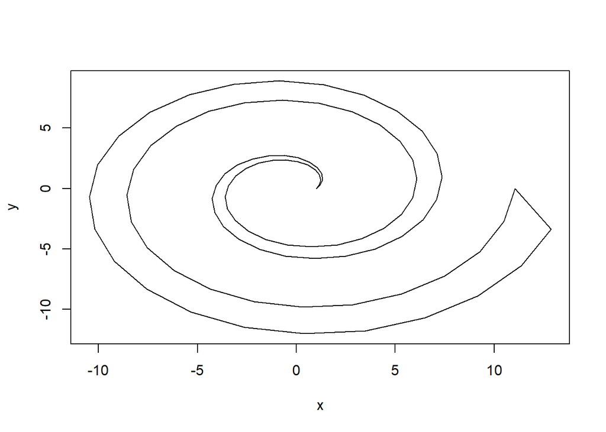

```r
theta <- seq(0, 4*pi, len = 50)
r <- theta + 1
r <- c(r[-50], rev(theta*0.8) + 1)
theta <- c(theta[-50], rev(theta))
x <- r*cos(theta)
y <- r*sin(theta)
plot(x, y, type = "n")
polygon(x, y)
```

```r
polygon3d(x, y, x + y, fill=T, col = "blue")
```

### triangulate()

This algorithm decomposes a general polygon into simple polygons and uses the “ear-clipping” algorithm to triangulate it.

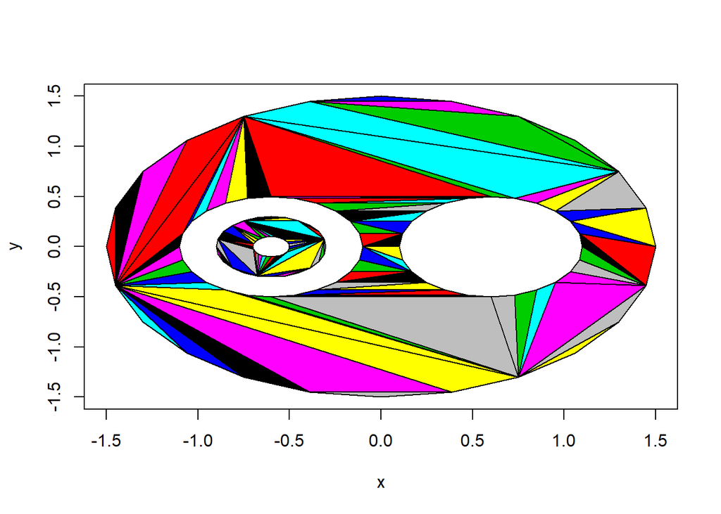

```
##      [,1] [,2] [,3] [,4] [,5] [,6] [,7] [,8] [,9] [,10] [,11] [,12] [,13]
## [1,]   65   14   14   64   14   21   63   62   21    62    61    60    59
## [2,]   64   66   67   63   21   68   62    9   69    61    60    59    58
## [3,]   14   65   66   14   67   67   14   14   68     9     9     9     9
##      [,14] [,15] [,16] [,17] [,18] [,19] [,20] [,21] [,22] [,23] [,24]
## [1,]    21    58    57    32    44    31    31    30    21    44    43
## [2,]    44    57    32    31    70     3    30    29    45    43    42
## [3,]    69     9     9     9    69     9     3     3    44    70    70
##      [,25] [,26] [,27] [,28] [,29] [,30] [,31] [,32] [,33] [,34] [,35]
## [1,]    21    42    21    21    42    41    41    40    40    40    40
## [2,]    46    71    47    24    41    72    40    73    74    51    39
## [3,]    45    70    46    47    71    71    72    72    73    74    51
##      [,36] [,37] [,38] [,39] [,40] [,41] [,42] [,43] [,44] [,45] [,46]
## [1,]    57    39    29    38    37    37    37    36    24    14    24
## [2,]    56    38     2    37    52    53    36    35    48    20    49
```

[output cut: 42 more lines]

```r
theta <- seq(0, 2*pi, len = 25)[-25]
theta <- c(theta, NA, theta, NA, theta, NA, theta, NA, theta)
r <- c(rep(1.5, 24), NA, rep(0.5, 24), NA, rep(0.5, 24), NA, rep(0.3, 24), NA, rep(0.1, 24))
dx <- c(rep(0, 24), NA, rep(0.6, 24), NA, rep(-0.6, 24), NA, rep(-0.6, 24), NA, rep(-0.6, 24))
x <- r*cos(theta) + dx
y <- r*sin(theta)
plot(x, y, type = "n")
polygon(x, y)
triangulate(x, y, plot = TRUE)
```

```r
open3d()
```

```
## wgl
##   9
```

```r
polygon3d(x, y, x - y, col = "royalblue")
```

### extrude3d()

If you have a 2d polygon you can change it to 3d using the extrude3d() function. Triangulates the polygon and creates a cylinder with that shape as the end faces.

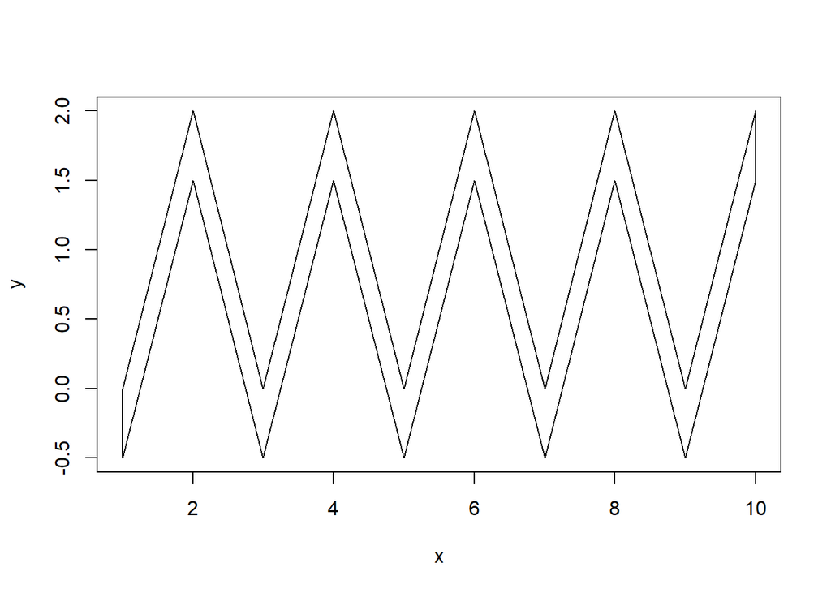

```r
x <- c(1:10, 10:1)
y <- rev(c(rep(c(0, 2), 5), rep(c(1.5, -0.5), 5)))
plot(x, y, type = "n")
polygon(x, y)
```

```r
open3d()
```

```
## wgl
##  10
```

```r
shade3d( extrude3d(x, y), col = "red" )
```

### GramSchmidt()

Generate a 3x3 orthogonal matrix using the Gram-Schmidt algorithm.

```r
# Proceed through the rows in order
print(A <- matrix(rnorm(9), 3, 3))
```

```
##          [,1]       [,2]       [,3]
## [1,] 1.027703 -0.1267063  0.4706120
## [2,] 0.360242 -1.2470488  0.3162419
## [3,] 1.686658 -0.5145499 -0.9169564
```

```r
GramSchmidt(A[1, ], A[2, ], A[3, ])
```

```
##          [,1]       [,2]       [,3]
## v1  0.9035459 -0.1113989  0.4137573
## v2 -0.1484908 -0.9871831  0.0584814
## v3  0.4019395 -0.1142798 -0.9085069
```

```r
# Keep the middle row unchanged
print(A <- matrix(c(rnorm(2), 0, 1, 0, 0, rnorm(3)), 3, 3, byrow = TRUE))
```

```
##            [,1]        [,2]      [,3]
## [1,] -0.7453818 -0.46265253  0.000000
## [2,]  1.0000000  0.00000000  0.000000
## [3,] -0.8390296  0.01287432 -0.133287
```

```r
GramSchmidt(A[1, ], A[2, ], A[3, ], order = c(2, 1, 3))
```

```
##    [,1] [,2] [,3]
## v2    0   -1    0
## v1    1    0    0
## v3    0    0   -1
```

### planes3d() & rgl.planes()

Add mathematical planes to a scene.

```r
open3d()
```

```
## wgl
##  11
```

```r
x <- rnorm(100)
y <- rnorm(100)
z <- 0.2*x - 0.3*y + rnorm(100, sd = 0.3)
fit <- lm(z ~ x + y)
plot3d(x, y, z, type = "s", col = "red", size = 1)

coefs <- coef(fit)
a <- coefs["x"]
b <- coefs["y"]
c <- -1
d <- coefs["(Intercept)"]
planes3d(a, b, c, d, alpha = 0.5)

open3d()
```

```
## wgl
##  12
```

```r
ids <- plot3d(x, y, z, type = "s", col = "red", size = 1, forceClipregion = TRUE)
oldid <- useSubscene3d(ids["clipregion"])
clipplanes3d(a, b, c, d)
useSubscene3d(oldid)
```

### Changing the above shapes to differnet shapes

```r
vertices <- c(
     -1.0, -1.0, 0, 1.0,
      1.0, -1.0, 0, 1.0,
      1.0,  1.0, 0, 1.0,
     -1.0,  1.0, 0, 1.0
  )
  indices <- c( 1, 2, 3, 4 )

  open3d()
```

```
## wgl
##  13
```

```r
  wire3d( qmesh3d(vertices, indices) )

  # render 4 meshes vertically in the current view

  open3d()
```

```
## wgl
##  14
```

```r
  bg3d("royalblue")
  l0 <- oh3d(tran = par3d("userMatrix"), color = "royalblue" )
  shade3d( translate3d( l0, -6, 0, 0 ))
  l1 <- subdivision3d( l0 )
  shade3d( translate3d( l1 , -2, 0, 0 ), color = "coral", override = FALSE )
  l2 <- subdivision3d( l1 )
  shade3d( translate3d( l2 , 2, 0, 0 ), color = "azure1", override = TRUE )
  l3 <- subdivision3d( l2 )
  shade3d( translate3d( l3 , 6, 0, 0 ), color = "darkred" )
```

```r
rgl.clear()
rgl.bg(col = "white")
plot3d(x,y,z)

fit <- lm(z ~ poly(x,2) +poly(y,2) + x:y )

xnew <- seq(min(x), max(x), len=20)
ynew <- seq(min(y), max(y), len=20)
df <- expand.grid(x = xnew,
                  y = ynew)

df$z <- predict(fit, newdata=df)

surface3d(xnew, ynew, df$z, col=c("orange","green")[1+(df$z > 0)] )
```